# L2 Data Summary

## Contents

1. Coverage of phone numbers from the voter file and L2 data overall, by demographics, and by geography
   1. Overall
   2. By Demographics
   3. By County
2. Race Imputation quality by comparing the imputed race from L2 to the ground truth from the voter file
   1. Aggregate Proportions
   2. Individual Labels
3. A comparison of voter status classification, specifically comparing the state labels of active voters to the labels from L2
4. A discussion of which voters are missing from the L2 Data
   1. Demographics
   2. Geography

It is important to note, unless otherwise specified, the below analysis focuses solely on *active voters*. For this, I use the Florida voter file’s classification of active voters as this is what will be used by the state. In the section on voter status classification, the full voter file is used.

## Coverage

This section is about the coverage of phone numbers that are available. I first discuss the overall voter file, before breaking coverage down by demographic information and then by geography.

### Overall coverage

[interactive chart not shown]

Figure 1: Overall Phone Number Coverage

Figure 1 above shows the percent coverage of phone numbers in the voter file and in the L2 data. L2 has two phone number columns available, one being for cell phones (or numbers that they are fairly confident are cell phones), and another column that is just any phone number they were able to find. As we can see, there are massive improvements in overall coverage even just between the voter file phone numbers and cell phones from L2. L2 has a cell phone number for approximately 69% of the state, and has *any* phone number for around 78% of the state. In the voter file however, there are only phone numbers available for 44% of active voters.

It is also worthwhile to compare the phone numbers that are from the voter file to the numbers provided by L2. To do this, I first cleaned the phone numbers to make sure they were all formatted the same way: as 10 digit numbers without any extensions. Due to data entry errors in the voter file, however, some of these phone numbers are not usable and would not have a match in the L2 data. In the table below, I summarize my comparison of the phone numbers from L2 and the voter file phone numbers.

L2 and Voter File Phone Number Comparison

|  | Percent | n |
| --- | --- | --- |
| Match Cell | 28.99% | 3,872,538 |
| Match Landline | 3.99% | 533,584 |
| L2 only | 35.03% | 4,679,947 |
| Voter file only | 3.58% | 478,808 |
| No Number in Either | 21.94% | 2,930,989 |
| Different numbers | 6.47% | 864,453 |

From this data, we see that the majority of the phone numbers are exclusive to L2, meaning we’re able to reach an additional 35% of active voters using the L2 data. For 29% of voters, the cell number in the voter file was the same as what was provided by L2. Unfortunately, we still do not have a phone number for 22% of voters. Furthermore, we can see that 4% of the phone numbers in the voter file are landlines, and interestingly 3.6% of voters provided a phone number in the voter file, but L2 was not able to find a phone number for them elsewhere.

### Coverage by Demographic

While understanding how we are improving our coverage of Florida overall is important, certain groups of people are harder to contact than others, making it vitally important that we have good quality coverage for each demographic group. The figure below shows the same coverage calculations as before, but broken down by age, gender, party registration, and race (self reported from the counties, not L2 imputed race).

[interactive chart not shown]

Figure 2: Phone Coverage by Demographic and Phone Number Source

As shown in Figure 2, across the board we see that the L2 cell phone numbers have much better coverage than the voter file phone numbers. As expected, there is not a single demographic group that has better coverage from the voter file than the L2 data. There are, however, some groups where the coverage improvement is not particularly large. For instance, with 18-24 year olds, 37% of these voters have a phone number in the voter file. L2 was able to find a cell number for 43% of these voters, which is significantly lower than any other demographic group; the next lowest is 25-34 year olds at 62%, almost 20 percentage points higher! As expected, older voters are more likely to have a phone number available in either dataset.

While the L2 data generally follows the same trends as the voter file (i.e., whichever group has better coverage in the voter file also tends to have better coverage in the L2 data), there are a few instances where this is not the case. For instance, in the voter file, 45% of female voters have a phone number available, but only 42% of males have a phone number. However, with L2 cell phone numbers, this gap is flipped and shrunk: 68% of female voters have a cell phone number in L2, but 70% of male voters have a cell phone number available in L2.

Where these trends become the most beneficial for us is with partisans. In the voter file, only 42% of registered Republicans and 47% of Democrats had a phone number available. In L2, this dramatically increases with 69% of Republicans and 70% of Democrats having cell phone numbers. Not only is the coverage greatly improved by the L2 data, but the *gap in coverage* is also meaningfully reduced.

### Coverage by County

The last area I examine coverage by is by geography, shown in Figure 3. Again, L2 provides significantly improved geographic coverage compared to using the voter file phone numbers, as shown in the figure below. On average, L2 provided cell phone numbers for 18% points more voters than the phone numbers available in the voter file. There are, however, some areas where these improvements are greater than others.

[interactive chart not shown]

Figure 3: The Geographic Distribution of Coverage

For instance, in Marion County and Seminole County, only *5-6%* of voters provide a phone number. L2, however, was able to find a cell phone number for 55% of voters in Marion County and 57% of voters in Seminole County. Martin County, similarly, only had phone numbers for 19% of voters, but L2 found cell phone numbers for 63% of voters. Only in one county did the voter file contain more cell phone numbers than were made available in L2. In Gulf County, 69% of residents had a phone number in the voter file, however L2 only found cell phone numbers for 67% of these voters. However, using all phone numbers L2 found, L2 provided phone numbers for 78% of voters in Gulf county.

Another noteworthy trend in this data is not just the increased coverage in the L2 data, it is the consistency of the coverage for L2. The county where L2 provided the least amount of cell phone numbers is Lafayette county at 52% (compared to 30% in the voter file), while the highest coverage was Broward County at 71% (61% in the voter file). With the voter file phone numbers, however, this range is much wider, with the least covered county being 5%, and the highest being 69%. To put this into perspective, the standard deviation of coverage from the voter file is ~12%. The standard deviation of coverage for the L2 cell phone numbers is one third of that at 4%. This means that using the L2 cell phone numbers will allow us to much more consistently contact voters in Florida.

## Race Imputation

In this section, I compare the racial group labels from the Florida voter file to the labels provided by L2. L2 uses computational methods to impute race. While L2 does not make it public what method they use for race imputation, they are most likely using Bayesian Improved Surname Geocoding for their racial imputation since this is the most commonly used approach. A positive in their data is that they provide richer racial group labels than whit is provided in the voter file. However, this comes at the cost of decreased precision of these estimates, lower sample size per category, and possibly introducing noise in anything using these estimates.

To make comparisons feasible, the first thing I do is group the racial group labels into one of five categories: White, Hispanic, Black, Asian, or Other. I do this with bother the voter file labels and the L2 labels. The voter file labels are fairly straightforward to group in this way, however, there are significantly more racial/ethnic groups in the L2 data. The code chunk below shows each possible ethnicity label in the L2 data. These are in four separate vectors, with the name of the vector being the racial group that an ethnic label is assigned to. There are only four vectors as L2 only provides one label for Hispanic voters. These comparisons are also using only the 11,364,571 that had race available in the voter file.

**Racial Group Labels**

```r
#White
c('English/Welsh', 'Scots', 'Irish', 'Manx', 'German', 'Austrian', 'Swiss', 'Dutch (Netherlands)',
  'Belgian', 'Luxembourgian', 'French', 'Basque', 'Italian', 'Maltese', 'Greek', 'Portuguese',
  'Norwegian', 'Danish', 'Swedish', 'Finnish', 'Icelandic', 'Estonian', 'Latvian', 'Lithuanian',
  'Polish', 'Czech', 'Slovakian', 'Hungarian', 'Romanian', 'Moldavian', 'Bulgarian', 'Serbian',
  'Croatian', 'Slovenian', 'Bosnian Muslim', 'Macedonian', 'Albanian', 'Byelorussian', 'Ukrainian',
  'Russian (omitting former Soviet States)', 'Georgian', 'Armenian', 'Azerb', 'Chechnian',
  'Arab', 'Persian', 'Turkish', 'Kurdish', 'Australian', 'New Zealand') -> white_groups

#Asian
c('Indian/Hindu', 'Pakistani', 'Bangladeshi', 'Sri Lankan', 'Nepalese', 'Bhutanese', 'Maldivian',
  'Tibetan', 'Afghan', 'Chinese', 'Japanese', 'Korean', 'Mongolian', 'Vietnamese', 'Laotian',
  'Khmer', 'Thai', 'Myanmar (Burmese)', 'Malay', 'Indonesian', 'Filipino', 'Unknown Asian',
  'Uzbek', 'Kazak', 'Kirghiz', 'Tajik', 'Turkmenistan',
  'Hawaiian', 'Western Samoa', 'Tonga', 'Papua New Guinea') -> asian_groups

#Black
c('African or Af-Am Self Reported', 'Likely Af-Am (Modeled)') -> black_groups

#Other
c('Native American', 'Multi-Ethnic', 'Surinam', 'Guyana') -> other_groups
```

I don’t have any reason to expect that these results would not generalize outside of Florida. While there are clear limitations to the method (see Argyle and Barber (2024) for a good discussion of some of these limitations), there is not much reason to suspect that these limitations are different in Florida than in other states. At a minimum, most potential confounds that would reduce the quality of their race imputations (such as Census Tract level income) are observable.

### Aggregate Proportions

Many researchers argue that given the ethical concerns around imputing race, that it is best practice to only use imputed race to generate aggregate proportions of racial groups (e.g., [Lockhart, King, and Musch, 2023](https://www.nature.com/articles/s41562-023-01587-9.pdf)). Additionally, there are many areas of research where the aggregate proportions of each racial group are sufficient or even necessary for the analysis being conducted. As such, Figure 4 below shows the aggregate proportion of each racial group using the county provided labels and using the labels from L2s imputed race.

[interactive chart not shown]

Figure 4: A Comparison of Aggregate Racial Proportions for L2 and Voter File Labels

The imputed proportions for each group are very similar to the ground truth. L2 does over classify voters as Hispanic with there being 3.6% points more Hispanic voters in the L2 labels than in the voter file. One possible source for this error could be some Hispanic voters choosing to classify themselves as white when registering to vote, however there is not much evidence for that beyond the magnitude of these discrepancies, as L2 also under classifies voters as white by 1.4% points, while over classifying Hispanic and Black voters by 3.6% points and 0.4% points respectively. Asian voters are essentially on target; but there are also significantly fewer voters classified as “other” in the L2 labels. This is likely due to how fine grained their labels are, making it easier to bin voters into one of the remaining 4 categories when I was cleaning the data.

### Individual Labels

Next I examine the performance of the individual level labels. This will be particular informative for anyone examining individual level behavior, and help us better understand why the state level aggregate proportions look the way they do. For this, I look at overall accuracy, recall, precision, and F1-scores. Accuracy measures the overall rate of correct labels, and is 93% for the 11,364,571 voters that have race included in the voter file. Recall is the rate of people from a racial group being correctly identified as such. In other words, it is the proportion of positively identified cases to all true positive cases, and can be expressed as: $\frac{TP}{TP+FN}$ where $TP$ is all true positive cases, and $FN$ is all false negative cases. Precision is the proportion of voters that are correctly classified as being part of a particular racial group to all voters who were classified as being in that group. Formally, precision is estimated as $\frac{TP}{TP+FP}$, with $FP$ being all false positive cases. F1 is a summary statistic of precision and recall that is most commonly used in machine learning to rate the quality of predictive classifications. F1 is formally is $2*\frac{precision*recall}{precision+recall}$ which written in terms of true and false positive and negative cases, can be written as $\frac{2TP}{2TP+FP+FN}$.

Race Classification Performance

| Race | Recall | Precision | F1 |
| --- | --- | --- | --- |
| White | 0.94 | 0.97 | 0.96 |
| Hispanic | 1.00 | 0.85 | 0.92 |
| Black | 1.00 | 0.97 | 0.99 |
| Asian | 0.60 | 0.65 | 0.62 |
| Other | 0.11 | 0.97 | 0.20 |

These scores generally indicate that their predictive model for race is performing fairly well, with two notable exceptions. The first is for Asian voters, with recall at 0.6, precision at 0.65, and an F1 score of 0.62. While that performance is better than some other contexts, it is still fairly poor compared to the other racial groups. The second group that their model does not perform well with the “Other” category. The precision for this label is very high at 0.97, meaning that the overwhelming majority of cases that were identified as “Other” were true positives. However, the recall of this group is only 0.11, resulting in an F1 of 0.2. The main cause for this appears to be the granularity of the ethnicity labels they provide. L2 does not use “Other” as an ethnicity category; because of this, many voters who likely self-identified as “other” were placed into one of the other racial groups since their imputed ethnicity is a closer match.

Overall, these results suggest that the binned racial groups should be usable for some research. At a minimum, scholars should be able to use the labels for “white” voters confidently, and classify them as being either “white” or “non-white.” The recall, precision, and F1 for white voters are all very high, meaning that their imputation model performs well at identifying white voters. I believe that this is one of the suggestions from Lockhart, King, and Musch (2023), but is also a practice common from other scholars (in particular, researchers using the `ethnicolr` package in python regularly take this approach). Also, anyone who is using the L2 data would also have all the information needed to create their own racial group estimates using other methods like `wru`’s BISG (or the extension for fBISG) or machine learning approaches like the `ethnicolr` package (or the `rethnicity` package in R, which is an extension of `ethnicolr` but with mixed performance in my personal experience).

## Active Voter Classification

Since we are able to merge the L2 data with the state’s original voter file, we can further examine how L2 is classifying voter status. It’s unclear from their documentation if they are classifying voter status through a predictive model, if they are reporting the state’s classification, or a mix of the two. Figure 5 below shows voter status as the state reports it, broken down by the categories from L2. The x-axis shows the voter status levels that are in the voter file, and the y-axis is the number of voters. The fill on each bar is the classification that L2 provided (or notes if they were missing).

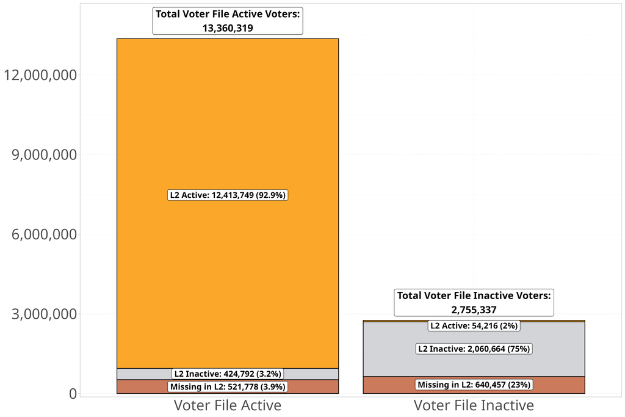

Figure 5: Voter Status Label Comparison

We can see above that the overwhelming majority of cases are correctly classified, 93% of all active voters were correctly classified as active, and 75% of inactive voters were classified as inactive. However, 3% of active voters were classified as inactive by L2 while 2% of inactive voters were classified as active. Additionally, there is a number of cases missing from L2 entirely that are found in the voter file. When I noticed this, my initial thought was that these were inactive voters that may have been purged from voter rolls when L2 collected the data, but still on them when we collected it, which is what lead to this analysis. As you can see above, that is not entirely the case. Of the 1,162,235 voters missing, 45% of them are active voters, and 55% are inactive. This nearly even split suggests that the missing voters from L2 are likely not just inactive voters.

## Missing Data

As mentioned above, there were a number of voters who were in the voter file we obtained from the state that were not present in the L2 data. The data from L2 was collected on 5/1/2026, and the voter file we collected from the state is from 5/12/2026. While there are certainly voters in the data that registered between these two dates, in my opinion, 11 days is not enough time to account for the 1,162,235 voters that were missing from L2.

To better understand who these missing voters are, in this section, I compare demographic characteristics (from the state provided voter file) and the geographic distribution of these voters to the voters that are in the L2 data. The purpose of this is to check if this missingness can be treated as missing at random, or if there is some underlying systematic problem causing this missing data. The short answer is that it’s probably not a cause for concern, and seems to be mostly missing at random. The likeliest sources of a voter being missing from L2 are them having a legal exemption from their information being public, being inactive, and the previously mentioned time gap. This, however, does not explain all the observed missingness, making a discussion of the missing data’s characteristics worthwhile.

### Demographics

First, Figure 6 below shows the demographic distribution of active and inactive voters, broken down by if they were or were not available in the L2 data. The purpose of this is to check if there are any concerns for sampling from the L2 data and to better understand the source of this missingness.

[interactive chart not shown]

Figure 6: Demographic composition of voters in and missing from the L2 data

First, exempt voters are clearly part of the issue, as none of the exempt voters were included in the L2 data. This is true for both active and inactive voters; 100% of active and inactive voters that in L2 are not exempt. However, only 85% of the active voters not in L2 were not exempt, leave some room for other sources of missing data. For reference, there are 85,813 total voters who are exempt from public records requests and 1,162,235 total voters missing from the L2 data.

Fortunately, among active voters, there are no other major disparities in the demographic composition of voters missing from L2 and those included. There are some relatively minor differences with White and Hispanic voters and some differences in the presence or absence of an email in the voter file, but these differences are not large. The one potential area for concern would be the active 18-24 year old voters, but again this gap overall seems negligable.

### Geographic Distribution

Figure 7 below shows the proportion of voters from a given county that are missing from the L2 data. There does not appear to be any major geographic concentration of this missingess. For most counties, between 5 and 10% of their voters are missing from the L2 data, the the highest rate of missingness being from Santa Rosa County at 12.5% missing (closely tied with Okaloosa County at 12.1%), and the county with the least missing voters is Baker County with 4.2% of their voters missing.

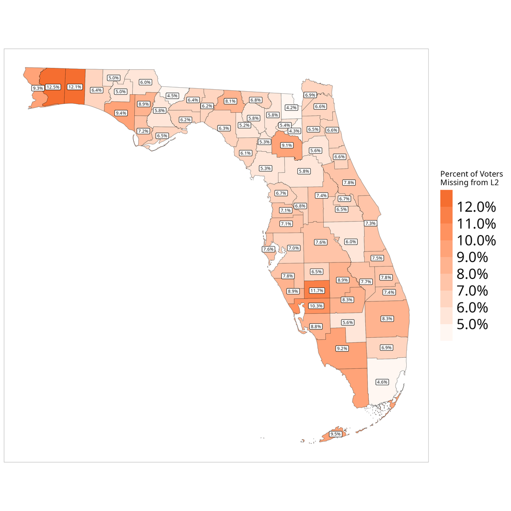